# Test 12: Fluorescein dilution serie

Jan Sklenar

09/06/2020

# Fluorimeter instrument test with Fluorecein

For some time I have a suspiccion that our spectofluorimeter, Varioskan (Thermo) is not sensitive enough. We have to use 10ul in the assay, while published protocols suggest to use only 1ul. We measure 40 ul in 96 well plates instead of 20ul in 384 though. These difference do not intuitivelly acount for lack of a signal in low concentration range. For this reason, Fluorescein disodium salt to benchmark sensitivity is used here. The chemical is of purity > 80%, which should be sufficient for rough estimate of sensitivity.

## Protocol:

1mM fluorescein disolved in water, further diluted to 100 times (5ul in 0.5ml) several times to low aM.

[output not shown]

## Data preparation

### Read in the data and parse some sample names

```r
## read in raw data
raw <- read.delim("data/200609_test_12_Fluorescein_topReading2020-06-09T184501.txt",stringsAsFactors = FALSE)
colnames(raw)
```

```
##  [1] "Reading"        "Plate"          "Well"           "Type"
##  [5] "Group"          "Sample"         "Meas..time..s." "RFU"
##  [9] "Em"             "Ex"             "X"
```

```r
head(raw)
```

```
##   Reading Plate Well    Type Group Sample Meas..time..s.      RFU  Em  Ex  X
## 1       1     1  A04 Unknown Assay  1 1/2           0.00 12169.60 520 490 NA
## 2       1     1  A05 Unknown Assay  1 2/2           0.25 12189.50 520 490 NA
## 3       1     1  A06 Unknown Assay  2 1/2           0.50 13071.90 520 490 NA
## 4       1     1  A07 Unknown Assay  2 2/2           0.75 13067.50 520 490 NA
## 5       1     1  B07 Unknown Assay  4 2/2           1.24  1468.52 520 490 NA
## 6       1     1  B06 Unknown Assay  4 1/2           1.49  1473.15 520 490 NA
```

```r
#' remove 'X' column
raw <- raw[,1:10]
#' change names
colnames(raw)[7]
```

```
## [1] "Meas..time..s."
```

```r
colnames(raw)[7] <- "MeasTimeSec"

#' parse 'Sample' to obtain sample number 'SampleNo'
raw$Sample[1]
```

```
## [1] "1 1/2"
```

```r
unique(raw$Sample)
```

```
##  [1] "1 1/2"  "1 2/2"  "2 1/2"  "2 2/2"  "4 2/2"  "4 1/2"  "3 2/2"  "3 1/2"
##  [9] "5 1/2"  "5 2/2"  "6 1/2"  "6 2/2"  "8 2/2"  "8 1/2"  "7 2/2"  "7 1/2"
## [17] "9 1/2"  "9 2/2"  "10 1/2" "10 2/2" "12 2/2" "12 1/2" "11 2/2" "11 1/2"
## [25] "13 1/2" "13 2/2" "14 1/2" "14 2/2" "16 2/2" "16 1/2" "15 2/2" "15 1/2"
```

```r
unique(raw$Well)
```

```
##  [1] " A04" " A05" " A06" " A07" " B07" " B06" " B05" " B04" " C04" " C05"
## [11] " C06" " C07" " D07" " D06" " D05" " D04" " E04" " E05" " E06" " E07"
## [21] " F07" " F06" " F05" " F04" " G04" " G05" " G06" " G07" " H07" " H06"
## [31] " H05" " H04"
```

```r
#substr(raw$Sample,1,regexpr(' ', raw$Sample)-1)
raw$SampleNo <- substr(raw$Sample,1,regexpr(' ', raw$Sample)-1)
raw
```

```
##    Reading Plate Well    Type Group Sample MeasTimeSec         RFU  Em  Ex
## 1        1     1  A04 Unknown Assay  1 1/2        0.00 1.21696e+04 520 490
## 2        1     1  A05 Unknown Assay  1 2/2        0.25 1.21895e+04 520 490
## 3        1     1  A06 Unknown Assay  2 1/2        0.50 1.30719e+04 520 490
## 4        1     1  A07 Unknown Assay  2 2/2        0.75 1.30675e+04 520 490
## 5        1     1  B07 Unknown Assay  4 2/2        1.24 1.46852e+03 520 490
## 6        1     1  B06 Unknown Assay  4 1/2        1.49 1.47315e+03 520 490
## 7        1     1  B05 Unknown Assay  3 2/2        1.74 1.85833e+02 520 490
## 8        1     1  B04 Unknown Assay  3 1/2        1.99 1.88276e+02 520 490
## 9        1     1  C04 Unknown Assay  5 1/2        2.70 1.02496e+00 520 490
## 10       1     1  C05 Unknown Assay  5 2/2        2.95 1.04405e+00 520 490
## 11       1     1  C06 Unknown Assay  6 1/2        3.43 7.76220e+00 520 490
## 12       1     1  C07 Unknown Assay  6 2/2        3.68 7.67079e+00 520 490
## 13       1     1  D07 Unknown Assay  8 2/2        4.14 2.67266e-01 520 490
## 14       1     1  D06 Unknown Assay  8 1/2        4.39 2.53112e-01 520 490
```

[output cut: 51 more lines]

```r
#' in the same way extract replicate number - 'RepNo'
#substr(raw$Sample,regexpr(' ', raw$Sample)+1, regexpr('/', raw$Sample)-1)
raw$RepNo <- substr(raw$Sample,regexpr(' ', raw$Sample)+1, regexpr('/', raw$Sample)-1)

#' remove white space from 'Well' sting
#substr(raw$Well, 2, regexpr('$', raw$Well))[1:5]
raw$Well<- substr(raw$Well, 2, regexpr('$', raw$Well))

#' convert SampleNo to factor in order it to sort nicely in ggplots
raw$SampleNo <- as.factor(raw$SampleNo)
#raw$SampleNo <- factor(raw$SampleNo, c(seq(1:7),"air"))
raw$SampleNo <- factor(raw$SampleNo, seq(1:16))
unique(raw$SampleNo)
```

```
##  [1] 1  2  4  3  5  6  8  7  9  10 12 11 13 14 16 15
## Levels: 1 2 3 4 5 6 7 8 9 10 11 12 13 14 15 16
```

```r
#' View(raw)
str(raw)
```

```
## 'data.frame':    32 obs. of  12 variables:
##  $ Reading    : int  1 1 1 1 1 1 1 1 1 1 ...
##  $ Plate      : int  1 1 1 1 1 1 1 1 1 1 ...
##  $ Well       : chr  "A04" "A05" "A06" "A07" ...
##  $ Type       : chr  "Unknown" "Unknown" "Unknown" "Unknown" ...
##  $ Group      : chr  "Assay" "Assay" "Assay" "Assay" ...
##  $ Sample     : chr  "1 1/2" "1 2/2" "2 1/2" "2 2/2" ...
##  $ MeasTimeSec: num  0 0.25 0.5 0.75 1.24 1.49 1.74 1.99 2.7 2.95 ...
##  $ RFU        : num  12170 12190 13072 13068 1469 ...
##  $ Em         : int  520 520 520 520 520 520 520 520 520 520 ...
##  $ Ex         : int  490 490 490 490 490 490 490 490 490 490 ...
##  $ SampleNo   : Factor w/ 16 levels "1","2","3","4",..: 1 1 2 2 4 4 3 3 5 5 ...
##  $ RepNo      : chr  "1" "2" "1" "2" ...
```

### Corrections - unnecessary

### Subset of data for plotting

```r
## Selected (cleaned) data, only columns needed for plotting
#' Well, Sample, SampleNo, RepNo, MeasTimeSec, RFU
colnames(raw)
```

```
##  [1] "Reading"     "Plate"       "Well"        "Type"        "Group"
##  [6] "Sample"      "MeasTimeSec" "RFU"         "Em"          "Ex"
## [11] "SampleNo"    "RepNo"
```

```r
df <- raw[,c(3,6,7,8,11,12)]
head(df)
```

```
##   Well Sample MeasTimeSec      RFU SampleNo RepNo
## 1  A04  1 1/2        0.00 12169.60        1     1
## 2  A05  1 2/2        0.25 12189.50        1     2
## 3  A06  2 1/2        0.50 13071.90        2     1
## 4  A07  2 2/2        0.75 13067.50        2     2
## 5  B07  4 2/2        1.24  1468.52        4     2
## 6  B06  4 1/2        1.49  1473.15        4     1
```

```r
#View(df)
str(df)
```

```
## 'data.frame':    32 obs. of  6 variables:
##  $ Well       : chr  "A04" "A05" "A06" "A07" ...
##  $ Sample     : chr  "1 1/2" "1 2/2" "2 1/2" "2 2/2" ...
##  $ MeasTimeSec: num  0 0.25 0.5 0.75 1.24 1.49 1.74 1.99 2.7 2.95 ...
##  $ RFU        : num  12170 12190 13072 13068 1469 ...
##  $ SampleNo   : Factor w/ 16 levels "1","2","3","4",..: 1 1 2 2 4 4 3 3 5 5 ...
##  $ RepNo      : chr  "1" "2" "1" "2" ...
```

```r
#' any problematic dAta
table(is.na(df))
```

```
##
## FALSE
##   192
```

```r
df[!complete.cases(df),]
```

```
## [1] Well        Sample      MeasTimeSec RFU         SampleNo    RepNo
## <0 rows> (or 0-length row.names)
```

## Plots

### All data

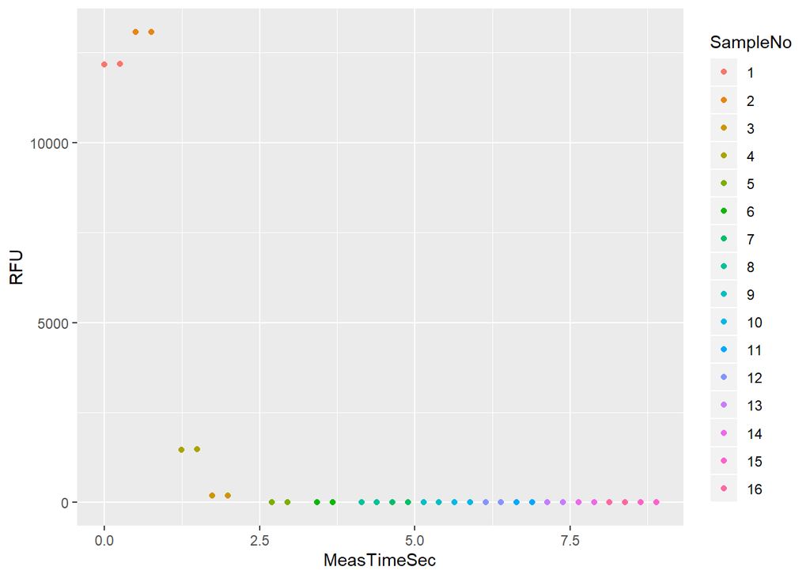

```r
#' all the data
#plot(x=raw$MeasTimeSec,y=raw$RFU)

#' colour by samples
ggplot(data = df) +
  aes(x = MeasTimeSec, y=RFU) +
  geom_point(aes(color=SampleNo))
```

### Adjustments - unnecessary

### Samples and conditions for plot legends

```r
## Description
name <- "Samples"
breaks <- as.character(seq(1:16))
str(breaks)
```

```
##  chr [1:16] "1" "2" "3" "4" "5" "6" "7" "8" "9" "10" "11" "12" "13" "14" ...
```

```r
breaks
```

```
##  [1] "1"  "2"  "3"  "4"  "5"  "6"  "7"  "8"  "9"  "10" "11" "12" "13" "14" "15"
## [16] "16"
```

```r
labels <-  c("1: 40ul 1mM",
            "2: 200ul 1mM",
            "3: 40ul 10uM",
            "4: 200ul 10uM",
            "5: 40ul 100nM",
            "6: 200ul 100nM",
            "7: 40ul 1nM",
            "8: 200ul 1nM",
            "9: 40ul 10pM",
            "10: 200ul 10pM",
            "11: 40ul 100fM",
            "12: 200ul 100fM",
            "13: 40ul 1fM",
            "14: 200ul 1fM",
            "15: 40ul 10aM",
            "16: 200ul 10aM")
```

### Final plots of subsets, samples, and conditions

[figure not shown]

```r
## Let us start with all data
## Bar plot
ggplot(data=df) +
  aes(x=SampleNo, y=RFU) +
  geom_bar(stat="identity",color="navyblue", fill="navyblue") +
  scale_y_continuous() +
  scale_x_discrete(labels=labels[1:16]) +
  theme(axis.text.x = element_text(angle = 90, hjust = 1)) +
labs(title= "Fluorescein dilution serie",
      subtitle = "purity  >80%",
     x="Dilutions",
     y= "RFU",
     caption = "Average of 2 replicates") +
  theme(plot.subtitle=element_text(size=10, hjust=0, face="italic", color="black"))
```

```r
## Subsets of interests are determined by volume in wells
# volume = 40ul
p1 <- df[df$SampleNo==1|df$SampleNo==3|df$SampleNo==5|df$SampleNo==7|df$SampleNo==9|df$SampleNo==11|df$SampleNo==13|df$SampleNo==15,]
# volume = 200ul
p2 <- df[df$SampleNo==2|df$SampleNo==4|df$SampleNo==6|df$SampleNo==8|df$SampleNo==10|df$SampleNo==12|df$SampleNo==14|df$SampleNo==16,]
# list
myplots <- list("p1"=p1,"p2"=p2)
class(myplots)
```

```
## [1] "list"
```

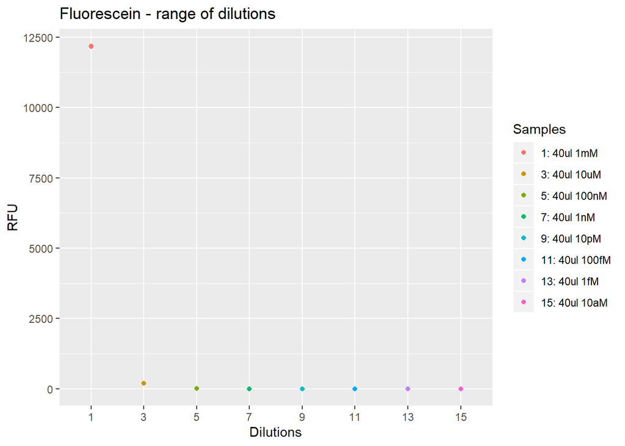

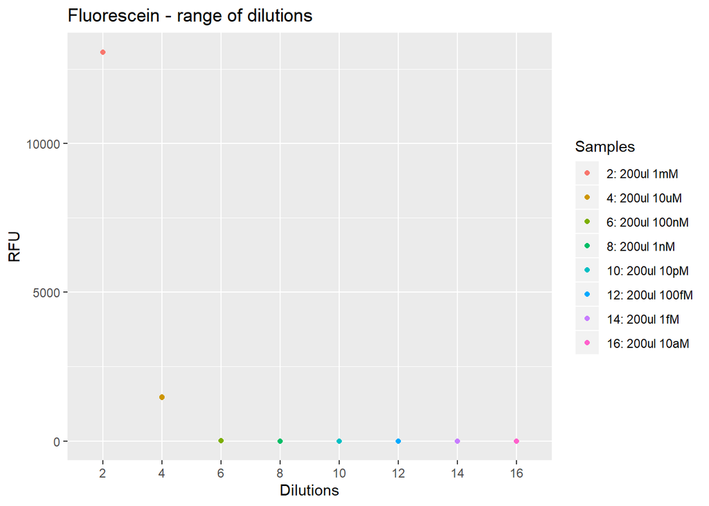

```r
#str(myplots)

# averave
#p1 %>% group_by(SampleNo) %>% summarise(mean=mean(RFU))

## Plots of different volumes individually
## normal scale
for(p in myplots){
p <- as.data.frame(p)

print(ggplot(data = p) +
  aes(x = SampleNo, y=RFU) +
  geom_point(aes(colour=SampleNo)) +
  labs(title = "Fluorescein - range of dilutions ", x = "Dilutions",   y = "RFU", color = "Legend Title\n") +
scale_colour_discrete(name=name, breaks=breaks, labels=labels))

}
```

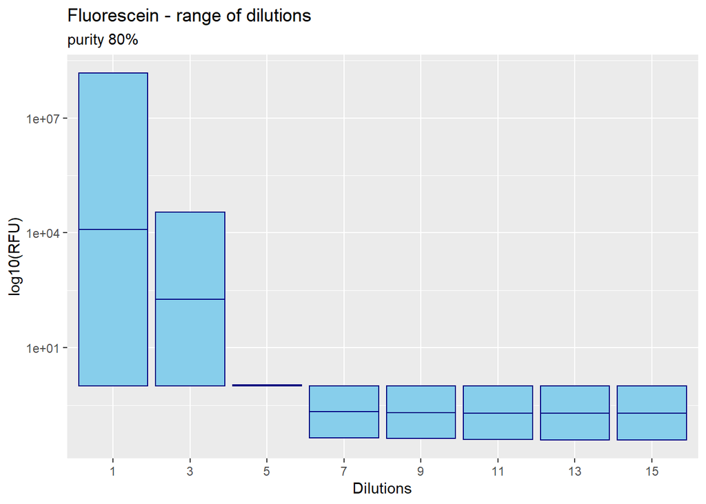

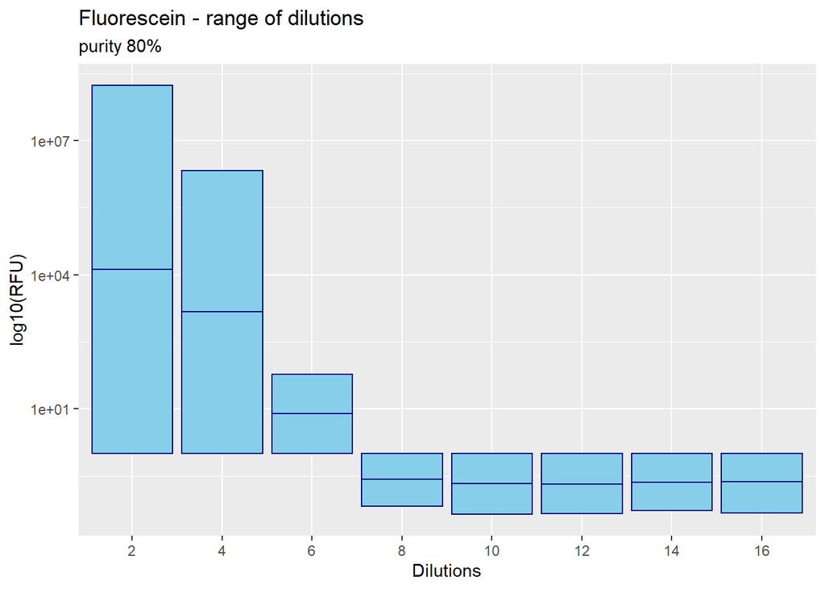

```r
## log scale
for(p in myplots){
p <- as.data.frame(p)

print(ggplot(data = p) +
  aes(x = SampleNo, y=RFU) +
  geom_bar(stat="identity",color="navyblue", fill="skyblue") +
  scale_y_log10() +
  labs(title = "Fluorescein - range of dilutions ",subtitle = "purity 80%", x = "Dilutions",   y = "log10(RFU)", color = "Legend Title\n") +
scale_colour_discrete(name=name, breaks=breaks, labels=labels))

}
```

### Notes:

- Fluorescein dilution serie  
  **High concentration:**  
  1mM = 1mmol /l = 1umol/ml = 1nmol/ul  
  In absolute values:  
  40ul => 40nmol  
  **Detection limit:**
- We can detect 100nM Fluorescein in larger volume (200ul) , which is 20pmol detected.

## Conclusions

### :-(

- Detection limit is still too high.

### What next?

- A different plate reader
- Bottom reading
- Fine adjustments
- Larger volume